# House Prices Modelling

Team:Ebrahim Adeeb

October 4, 2016

# Model 1: LM Model

## Data Step

**Load data train.csv from file as a dataframe and name it “train”.**

```r
train <- read.csv('train.csv',stringsAsFactors=T)
str(train)
```

```
## 'data.frame':    1460 obs. of  81 variables:
##  $ Id           : int  1 2 3 4 5 6 7 8 9 10 ...
##  $ MSSubClass   : int  60 20 60 70 60 50 20 60 50 190 ...
##  $ MSZoning     : Factor w/ 5 levels "C (all)","FV",..: 4 4 4 4 4 4 4 4 5 4 ...
##  $ LotFrontage  : int  65 80 68 60 84 85 75 NA 51 50 ...
##  $ LotArea      : int  8450 9600 11250 9550 14260 14115 10084 10382 6120 7420 ...
##  $ Street       : Factor w/ 2 levels "Grvl","Pave": 2 2 2 2 2 2 2 2 2 2 ...
##  $ Alley        : Factor w/ 2 levels "Grvl","Pave": NA NA NA NA NA NA NA NA NA NA ...
##  $ LotShape     : Factor w/ 4 levels "IR1","IR2","IR3",..: 4 4 1 1 1 1 4 1 4 4 ...
##  $ LandContour  : Factor w/ 4 levels "Bnk","HLS","Low",..: 4 4 4 4 4 4 4 4 4 4 ...
##  $ Utilities    : Factor w/ 2 levels "AllPub","NoSeWa": 1 1 1 1 1 1 1 1 1 1 ...
##  $ LotConfig    : Factor w/ 5 levels "Corner","CulDSac",..: 5 3 5 1 3 5 5 1 5 1 ...
##  $ LandSlope    : Factor w/ 3 levels "Gtl","Mod","Sev": 1 1 1 1 1 1 1 1 1 1 ...
##  $ Neighborhood : Factor w/ 25 levels "Blmngtn","Blueste",..: 6 25 6 7 14 12 21 17 18 4 ...
##  $ Condition1   : Factor w/ 9 levels "Artery","Feedr",..: 3 2 3 3 3 3 3 5 1 1 ...
```

[output cut: 67 more lines]

*dataframe “train” has* 1460 *Rows with* 81 *Columns*.

We noticed that “Alley”,“PoolQC”,“Fence”,“MiscFeature” have a high number of NA values so we remove them from the dataframe “train and test”.

“train” consists of **1460** rows and **77** columns. “test” consists of **1459** rows and **76** columns.

```r
head(train)
```

```
##   Id MSSubClass MSZoning LotFrontage LotArea Street LotShape LandContour
## 1  1         60        4          65    8450      2        4           4
## 2  2         20        4          80    9600      2        4           4
## 3  3         60        4          68   11250      2        1           4
## 4  4         70        4          60    9550      2        1           4
## 5  5         60        4          84   14260      2        1           4
## 6  6         50        4          85   14115      2        1           4
##   Utilities LotConfig LandSlope Neighborhood Condition1 Condition2
## 1         1         5         1            6          3          3
## 2         1         3         1           25          2          3
## 3         1         5         1            6          3          3
## 4         1         1         1            7          3          3
## 5         1         3         1           14          3          3
## 6         1         5         1           12          3          3
##   BldgType HouseStyle OverallQual OverallCond YearBuilt YearRemodAdd
```

[output cut: 76 more lines]

**The plot below is a visualization of correlations between our variables. The color of the circles represents the direction of the correlation (ie. Blue = positive, Red = negative). The size of the circles represents the strength of the correlation (ie. Large close to 1/-1, Small close to 0).**

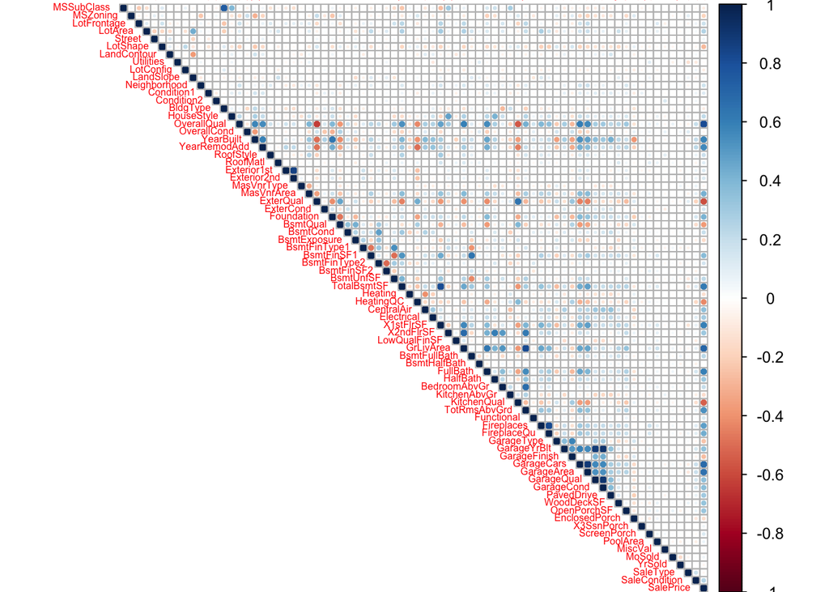

```r
train$SalePrice<-log(train$SalePrice)
correlations<- cor(train[,-1])
corrplot(correlations, method="circle", type="upper",  sig.level = 0.01, insig = "blank",tl.cex=0.5)
```

```r
most_correlated <- sort(abs(correlations[rownames(correlations) != "SalePrice",colnames(correlations)=="SalePrice"]),decreasing = T)
list_most_correlated <- names(most_correlated)
# The 12 most correlated variable
list_most_correlated[1:12]
```

```
##  [1] "OverallQual"  "GrLivArea"    "GarageCars"   "GarageArea"
##  [5] "TotalBsmtSF"  "X1stFlrSF"    "FullBath"     "YearBuilt"
##  [9] "ExterQual"    "YearRemodAdd" "TotRmsAbvGrd" "KitchenQual"
```

but let’s try plotting the outcome (log(SalePrice)) vs numeric columns.

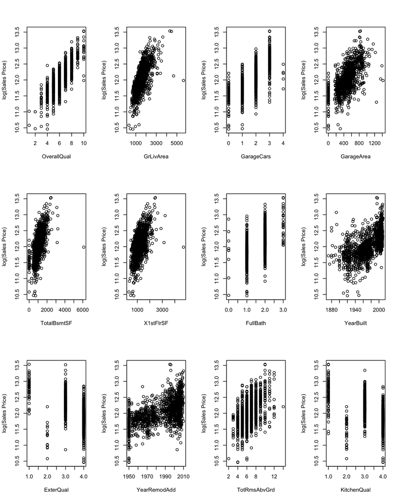

```r
# Create a grid of plots
par(mfrow=c(3, 4))
for(variable_ref in 1:12){
  plot(train[, colnames(train) == list_most_correlated[variable_ref]],train$SalePrice, xlab=list_most_correlated[variable_ref], ylab="log(Sales Price)")
}
```

```r
par(mfrow=c(1,1))
```

## Build a model and explore it

**Multiple linear models:**

- Linear regression is an approach for modeling the relationship between a scalar dependent variable y and one or more explanatory variables (or independent variables) denoted X. The case of one explanatory variable is called simple linear regression. For more than one explanatory variable, the process is called multiple linear regression.(This term should be distinguished from multivariate linear regression, where multiple correlated dependent variables are predicted, rather than a single scalar variable.)
- Multiple linear regression is the most common form of linear regression analysis. As a predictive analysis, the multiple linear regression is used to explain the relationship between one continuous dependent variable from two or more independent variables. The independent variables can be continuous or categorical (dummy coded as appropriate).

**Stepwise Regression:**

- Stepwise regression includes regression models in which the choice of predictive variables is carried out by an automatic procedure. Usually, this takes the form of a sequence of F-tests or t-tests, but other techniques are possible, such as adjusted R2, Akaike information criterion, Bayesian information criterion, Mallows’s Cp, PRESS, or false discovery rate.
- To build our model we will use Akaike information criterion (AIC) to evaluate which model to use.
- The approach for stepwise regression we use is backward elimination, which involves starting with all candidate variables, testing the deletion of each variable using a chosen model comparison criterion, deleting the variable (if any) that improves the model the most by being deleted, and repeating this process until no further improvement is possible.

```
##
## Call:
## lm(formula = SalePrice ~ ., data = train[, -1])
##
## Residuals:
##      Min       1Q   Median       3Q      Max
## -1.77182 -0.06370  0.00248  0.06631  0.53160
##
## Coefficients: (2 not defined because of singularities)
##                 Estimate Std. Error t value Pr(>|t|)
## (Intercept)    2.078e+01  5.769e+00   3.602 0.000327 ***
## MSSubClass    -2.289e-04  1.978e-04  -1.157 0.247380
## MSZoning      -1.708e-02  6.603e-03  -2.586 0.009799 **
## LotFrontage   -2.145e-04  1.218e-04  -1.761 0.078506 .
## LotArea        1.536e-06  4.630e-07   3.318 0.000929 ***
## Street         1.805e-01  6.106e-02   2.956 0.003166 **
## LotShape      -5.045e-03  2.970e-03  -1.698 0.089639 .
## LandContour    1.040e-02  5.887e-03   1.766 0.077630 .
## Utilities     -1.838e-01  1.452e-01  -1.266 0.205787
## LotConfig     -9.875e-04  2.369e-03  -0.417 0.676864
## LandSlope      3.312e-02  1.673e-02   1.980 0.047950 *
## Neighborhood   8.481e-04  6.862e-04   1.236 0.216699
## Condition1     1.576e-03  4.427e-03   0.356 0.721841
## Condition2    -4.459e-02  1.464e-02  -3.045 0.002368 **
## BldgType      -1.100e-02  6.479e-03  -1.697 0.089878 .
## HouseStyle    -4.491e-03  2.849e-03  -1.577 0.115124
## OverallQual    7.112e-02  5.168e-03  13.762  < 2e-16 ***
## OverallCond    4.054e-02  4.543e-03   8.924  < 2e-16 ***
## YearBuilt      1.539e-03  3.256e-04   4.728 2.50e-06 ***
## YearRemodAdd   6.973e-04  2.908e-04   2.398 0.016617 *
## RoofStyle      5.195e-03  4.898e-03   1.061 0.289001
## RoofMatl       9.954e-03  6.562e-03   1.517 0.129494
## Exterior1st   -3.737e-03  2.278e-03  -1.640 0.101196
## Exterior2nd    3.210e-03  2.059e-03   1.559 0.119210
## MasVnrType     5.590e-03  6.439e-03   0.868 0.385446
## MasVnrArea     1.788e-05  2.620e-05   0.682 0.495069
## ExterQual     -6.876e-03  8.566e-03  -0.803 0.422299
## ExterCond      1.047e-02  5.477e-03   1.911 0.056192 .
## Foundation     1.219e-02  7.339e-03   1.661 0.096853 .
## BsmtQual      -1.366e-02  5.920e-03  -2.307 0.021189 *
```

[output cut: 37 more lines]

```
## EnclosedPorch  1.532e-04  6.818e-05   2.247 0.024800 *
## X3SsnPorch     1.779e-04  1.267e-04   1.405 0.160330
## ScreenPorch    3.313e-04  7.008e-05   4.727 2.51e-06 ***
## PoolArea      -2.902e-04  9.613e-05  -3.019 0.002586 **
## MiscVal       -1.650e-06  7.593e-06  -0.217 0.827983
## MoSold         1.007e-04  1.391e-03   0.072 0.942284
## YrSold        -7.448e-03  2.851e-03  -2.613 0.009079 **
## SaleType      -1.678e-03  2.503e-03  -0.671 0.502592
## SaleCondition  2.258e-02  3.604e-03   6.265 4.96e-10 ***
## ---
## Signif. codes:  0 '***' 0.001 '**' 0.01 '*' 0.05 '.' 0.1 ' ' 1
##
## Residual standard error: 0.1385 on 1386 degrees of freedom
## Multiple R-squared:  0.8858, Adjusted R-squared:  0.8798
## F-statistic: 147.3 on 73 and 1386 DF,  p-value: < 2.2e-16
```

```
##
## Call:
## lm(formula = SalePrice ~ ., data = train[, (names(train) %in%
##     c("MSZoning", "LotArea", "Street", "LandSlope", "Condition2",
##         "OverallQual", "OverallCond", "YearBuilt", "YearRemodAdd",
##         "BsmtQual", "BsmtCond", "BsmtFinType1", "BsmtFinType2",
##         "BsmtFinSF2", "HeatingQC", "CentralAir", "X1stFlrSF",
##         "X2ndFlrSF", "BsmtFullBath", "FullBath", "KitchenQual",
##         "TotRmsAbvGrd", "Functional", "Fireplaces", "GarageCars",
##         "PavedDrive", "WoodDeckSF", "EnclosedPorch", "ScreenPorch",
##         "PoolArea", "YrSold", "SaleCondition", "SalePrice"))])
##
## Residuals:
##      Min       1Q   Median       3Q      Max
## -1.84105 -0.06941  0.00302  0.07678  0.59171
##
## Coefficients:
##                 Estimate Std. Error t value Pr(>|t|)
## (Intercept)    1.982e+01  5.691e+00   3.483 0.000512 ***
## MSZoning      -2.363e-02  6.315e-03  -3.741 0.000191 ***
## LotArea        2.202e-06  4.510e-07   4.882 1.17e-06 ***
## Street         2.128e-01  6.045e-02   3.521 0.000444 ***
## LandSlope      2.935e-02  1.545e-02   1.900 0.057689 .
## Condition2    -4.617e-02  1.444e-02  -3.198 0.001412 **
## OverallQual    7.452e-02  4.907e-03  15.188  < 2e-16 ***
## OverallCond    4.159e-02  4.431e-03   9.386  < 2e-16 ***
## YearBuilt      2.073e-03  2.637e-04   7.864 7.29e-15 ***
## YearRemodAdd   5.631e-04  2.811e-04   2.003 0.045372 *
## BsmtQual      -1.280e-02  5.513e-03  -2.321 0.020440 *
## BsmtCond       1.380e-02  5.507e-03   2.507 0.012293 *
## BsmtFinType1  -7.623e-03  2.424e-03  -3.146 0.001692 **
## BsmtFinType2   1.569e-02  4.616e-03   3.400 0.000693 ***
## BsmtFinSF2     9.925e-05  3.087e-05   3.215 0.001334 **
## HeatingQC     -9.644e-03  2.579e-03  -3.739 0.000192 ***
## CentralAir     8.311e-02  1.814e-02   4.583 4.99e-06 ***
## X1stFlrSF      2.616e-04  1.882e-05  13.902  < 2e-16 ***
## X2ndFlrSF      1.703e-04  1.664e-05  10.239  < 2e-16 ***
## BsmtFullBath   5.358e-02  8.612e-03   6.221 6.48e-10 ***
## FullBath       1.947e-02  1.032e-02   1.887 0.059393 .
## KitchenQual   -2.750e-02  5.843e-03  -4.707 2.76e-06 ***
## TotRmsAbvGrd   1.589e-02  4.206e-03   3.779 0.000164 ***
## Functional     1.862e-02  4.053e-03   4.595 4.71e-06 ***
## Fireplaces     3.858e-02  7.073e-03   5.455 5.75e-08 ***
## GarageCars     7.031e-02  6.913e-03  10.171  < 2e-16 ***
## PavedDrive     2.727e-02  8.845e-03   3.083 0.002090 **
## WoodDeckSF     1.377e-04  3.225e-05   4.271 2.08e-05 ***
## EnclosedPorch  1.838e-04  6.819e-05   2.696 0.007109 **
## ScreenPorch    3.785e-04  6.976e-05   5.425 6.79e-08 ***
## PoolArea      -3.247e-04  9.543e-05  -3.403 0.000685 ***
## YrSold        -7.500e-03  2.823e-03  -2.657 0.007969 **
## SaleCondition  2.380e-02  3.529e-03   6.744 2.22e-11 ***
## ---
## Signif. codes:  0 '***' 0.001 '**' 0.01 '*' 0.05 '.' 0.1 ' ' 1
##
## Residual standard error: 0.1412 on 1427 degrees of freedom
## Multiple R-squared:  0.8778, Adjusted R-squared:  0.8751
## F-statistic: 320.4 on 32 and 1427 DF,  p-value: < 2.2e-16
```

```
##
## Call:
## lm(formula = SalePrice ~ MSZoning + LotFrontage + LotArea + Street +
##     LotShape + LandContour + LandSlope + Condition2 + BldgType +
##     HouseStyle + OverallQual + OverallCond + YearBuilt + YearRemodAdd +
##     RoofStyle + RoofMatl + Exterior1st + Exterior2nd + ExterCond +
##     Foundation + BsmtQual + BsmtCond + BsmtExposure + BsmtFinType1 +
##     BsmtFinSF1 + BsmtFinType2 + BsmtFinSF2 + BsmtUnfSF + HeatingQC +
##     CentralAir + X1stFlrSF + X2ndFlrSF + LowQualFinSF + BsmtFullBath +
##     FullBath + HalfBath + KitchenAbvGr + KitchenQual + TotRmsAbvGrd +
##     Functional + Fireplaces + GarageType + GarageCars + GarageCond +
##     PavedDrive + WoodDeckSF + EnclosedPorch + X3SsnPorch + ScreenPorch +
##     PoolArea + YrSold + SaleCondition, data = train[, -1])
##
## Residuals:
##      Min       1Q   Median       3Q      Max
## -1.79584 -0.06363  0.00318  0.06836  0.54824
##
## Coefficients:
##                 Estimate Std. Error t value Pr(>|t|)
## (Intercept)    1.950e+01  5.609e+00   3.476 0.000524 ***
## MSZoning      -1.969e-02  6.268e-03  -3.142 0.001714 **
## LotFrontage   -1.854e-04  1.197e-04  -1.548 0.121814
## LotArea        1.511e-06  4.530e-07   3.336 0.000873 ***
## Street         1.722e-01  5.970e-02   2.885 0.003971 **
## LotShape      -5.928e-03  2.868e-03  -2.067 0.038920 *
## LandContour    1.053e-02  5.802e-03   1.814 0.069893 .
## LandSlope      3.240e-02  1.649e-02   1.965 0.049567 *
## Condition2    -4.398e-02  1.423e-02  -3.090 0.002042 **
## BldgType      -1.724e-02  3.712e-03  -4.643 3.75e-06 ***
## HouseStyle    -5.801e-03  2.523e-03  -2.299 0.021651 *
## OverallQual    7.186e-02  4.991e-03  14.399  < 2e-16 ***
## OverallCond    4.057e-02  4.477e-03   9.062  < 2e-16 ***
## YearBuilt      1.649e-03  3.109e-04   5.303 1.32e-07 ***
## YearRemodAdd   7.126e-04  2.827e-04   2.520 0.011833 *
## RoofStyle      6.735e-03  4.713e-03   1.429 0.153196
## RoofMatl       1.045e-02  6.483e-03   1.612 0.107193
## Exterior1st   -3.670e-03  2.235e-03  -1.642 0.100869
## Exterior2nd    3.053e-03  2.018e-03   1.513 0.130477
## ExterCond      1.026e-02  5.353e-03   1.918 0.055369 .
```

[output cut: 24 more lines]

```
## GarageCond     7.126e-03  4.321e-03   1.649 0.099305 .
## PavedDrive     2.453e-02  8.931e-03   2.747 0.006089 **
## WoodDeckSF     1.089e-04  3.216e-05   3.385 0.000732 ***
## EnclosedPorch  1.648e-04  6.715e-05   2.454 0.014240 *
## X3SsnPorch     1.837e-04  1.252e-04   1.467 0.142581
## ScreenPorch    3.247e-04  6.910e-05   4.699 2.86e-06 ***
## PoolArea      -2.994e-04  9.479e-05  -3.158 0.001621 **
## YrSold        -7.021e-03  2.779e-03  -2.527 0.011620 *
## SaleCondition  2.230e-02  3.479e-03   6.410 1.99e-10 ***
## ---
## Signif. codes:  0 '***' 0.001 '**' 0.01 '*' 0.05 '.' 0.1 ' ' 1
##
## Residual standard error: 0.138 on 1407 degrees of freedom
## Multiple R-squared:  0.8849, Adjusted R-squared:  0.8807
## F-statistic: 208.1 on 52 and 1407 DF,  p-value: < 2.2e-16
```

```
##              Step Df     Deviance Resid. Df Resid. Dev       AIC
## 1                 NA           NA      1386   26.58047 -5700.782
## 2     - GrLivArea  0 0.000000e+00      1386   26.58047 -5700.782
## 3   - TotalBsmtSF  0 0.000000e+00      1386   26.58047 -5700.782
## 4   - FireplaceQu  1 9.663641e-05      1387   26.58057 -5702.777
## 5        - MoSold  1 1.032302e-04      1388   26.58067 -5704.771
## 6       - MiscVal  1 9.131799e-04      1389   26.58158 -5706.721
## 7   - GarageYrBlt  1 8.681872e-04      1390   26.58245 -5708.673
## 8    - GarageQual  1 5.661134e-04      1391   26.58302 -5710.642
## 9    - GarageArea  1 1.144032e-03      1392   26.58416 -5712.579
## 10   - Condition1  1 2.170984e-03      1393   26.58633 -5714.460
## 11   - Electrical  1 2.874903e-03      1394   26.58921 -5716.302
## 12    - LotConfig  1 2.919331e-03      1395   26.59213 -5718.142
## 13      - Heating  1 2.961040e-03      1396   26.59509 -5719.979
## 14  - OpenPorchSF  1 6.144533e-03      1397   26.60123 -5721.642
## 15     - SaleType  1 9.464760e-03      1398   26.61070 -5723.123
## 16   - MasVnrArea  1 1.082521e-02      1399   26.62152 -5724.529
## 17   - MasVnrType  1 1.071763e-02      1400   26.63224 -5725.941
## 18 - BedroomAbvGr  1 1.376953e-02      1401   26.64601 -5727.186
## 19    - ExterQual  1 1.313029e-02      1402   26.65914 -5728.467
## 20 - GarageFinish  1 2.313018e-02      1403   26.68227 -5729.201
## 21   - MSSubClass  1 2.384479e-02      1404   26.70611 -5729.897
## 22    - Utilities  1 2.247983e-02      1405   26.72859 -5730.668
## 23 - Neighborhood  1 2.707759e-02      1406   26.75567 -5731.190
## 24 - BsmtHalfBath  1 3.422855e-02      1407   26.78990 -5731.323
```

```
## Analysis of Variance Table
##
## Model 1: SalePrice ~ MSZoning + LotArea + Street + LandSlope + Condition2 +
##     OverallQual + OverallCond + YearBuilt + YearRemodAdd + BsmtQual +
##     BsmtCond + BsmtFinType1 + BsmtFinType2 + BsmtFinSF2 + HeatingQC +
##     CentralAir + X1stFlrSF + X2ndFlrSF + BsmtFullBath + FullBath +
##     KitchenQual + TotRmsAbvGrd + Functional + Fireplaces + GarageCars +
##     PavedDrive + WoodDeckSF + EnclosedPorch + ScreenPorch + PoolArea +
##     YrSold + SaleCondition
## Model 2: SalePrice ~ MSZoning + LotFrontage + LotArea + Street + LotShape +
##     LandContour + LandSlope + Condition2 + BldgType + HouseStyle +
##     OverallQual + OverallCond + YearBuilt + YearRemodAdd + RoofStyle +
##     RoofMatl + Exterior1st + Exterior2nd + ExterCond + Foundation +
##     BsmtQual + BsmtCond + BsmtExposure + BsmtFinType1 + BsmtFinSF1 +
##     BsmtFinType2 + BsmtFinSF2 + BsmtUnfSF + HeatingQC + CentralAir +
##     X1stFlrSF + X2ndFlrSF + LowQualFinSF + BsmtFullBath + FullBath +
##     HalfBath + KitchenAbvGr + KitchenQual + TotRmsAbvGrd + Functional +
##     Fireplaces + GarageType + GarageCars + GarageCond + PavedDrive +
##     WoodDeckSF + EnclosedPorch + X3SsnPorch + ScreenPorch + PoolArea +
##     YrSold + SaleCondition
##   Res.Df    RSS Df Sum of Sq      F    Pr(>F)
## 1   1427 28.445
## 2   1407 26.790 20    1.6551 4.3463 5.734e-10 ***
## ---
## Signif. codes:  0 '***' 0.001 '**' 0.01 '*' 0.05 '.' 0.1 ' ' 1
```

**Below is our residual plots for the regression model. Residual plots are used to confirm the validity of our model.**

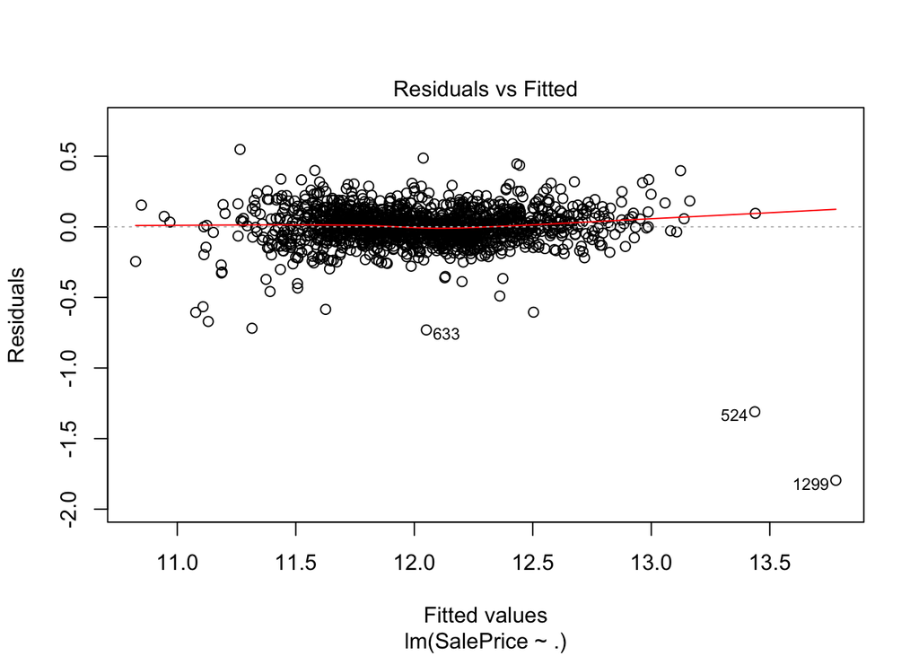

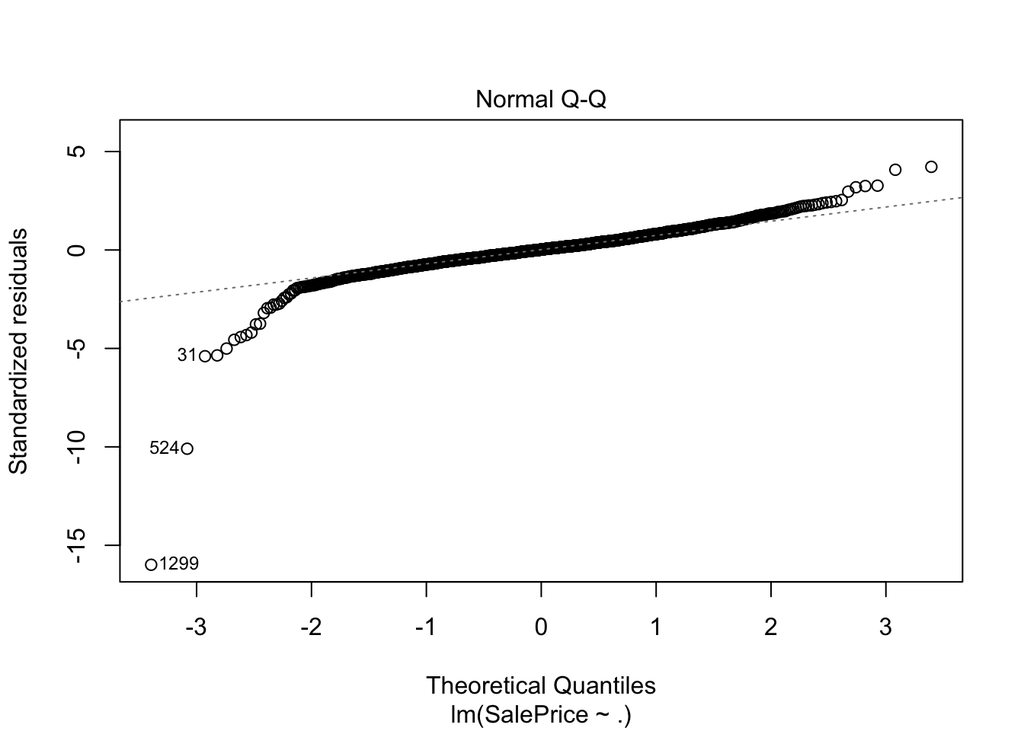

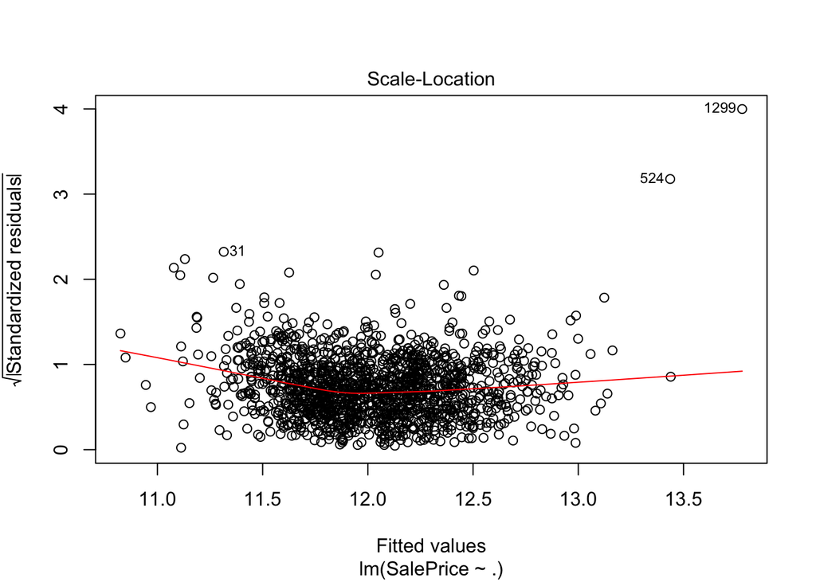

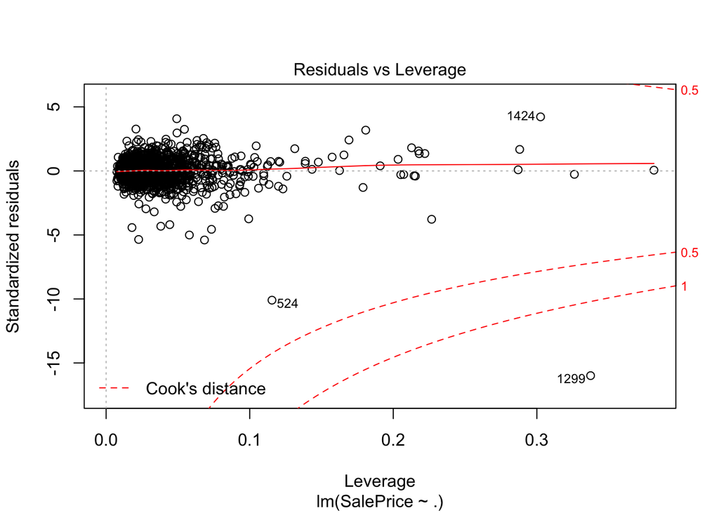

```r
plot(lm.train)
```

## Validation

**Definition:**

- Cross-validation, sometimes called rotation estimation,is a model validation technique for assessing how the results of a statistical analysis will generalize to an independent data set. It is mainly used in settings where the goal is prediction, and one wants to estimate how accurately a predictive model will perform in practice. In a prediction problem, a model is usually given a dataset of known data on which training is run (training dataset), and a dataset of unknown data (or first seen data) against which the model is tested (testing dataset). The goal of cross validation is to define a dataset to “test” the model in the training phase (i.e., the validation dataset), in order to limit problems like overfitting, give an insight on how the model will generalize to an independent dataset.
- Leave-one-out cross-validation involves using p=1 observations as the validation set and the remaining observations as the training set. This is repeated on all ways to cut the original sample on a validation set of p=1 observations and a training set.

```r
# leave-one-out cross-validation
out_of_sample_prediction <- rep(NA, nrow(train))
for(data_point in 1:(nrow(train))){
  # Fit model on data with point left out
  # lm_model_loo <- lm(SalePrice ~ OverallQual + GrLivArea , data = train[-data_point, ])
  out_of_sample_prediction[data_point] <- predict(lm.train, newdata = train[data_point, -1])
}
```

```r
eval_metric(out_of_sample_prediction, train$SalePrice)
```

```
## [1] 0.0112742
```

```r
predicted_values_lm <- predict(lm.train, newdata = test[,-1])
predicted_values_lm<-exp(predicted_values_lm)
```

Our Evaluation Metric Score is: 0.0112742.

[output not shown]

## Model 2: Sung lm model

*Sung Ha scored 0.12794 on Kaggle’s leaderboard*

### Stepwise regression and AIC

#### Load in and explore data

```r
house_prices_data <- read.csv('train.csv', stringsAsFactors = FALSE)
#str(house_prices_data)
house_prices_data_test <- read.csv('test.csv', stringsAsFactors = FALSE)
```

```r
train_sung <- house_prices_data %>% mutate_if(is.character, as.factor)
#str(train_sung)
n_na <-sapply(train_sung,function(y)length(which(is.na(y)==T)))
n_na.df<- data.frame(var=colnames(train_sung),num_NA=n_na)

train_sung <- train_sung[,!(names(train_sung)%in%c("Id","Alley","PoolQC","Fence","MiscFeature"))]

num<-sapply(train_sung,is.numeric)
num<-train_sung[,num]

for(i in 1:76){
  if(is.factor(train_sung[,i])){
    train_sung[,i]<-as.integer(train_sung[,i])
  }
}
train_sung[is.na(train_sung)]<-0
num[is.na(num)]<-0

train.train<- train_sung[1:floor(length(train_sung[,1])*0.8),]
train.train$SalePrice <- log(train.train$SalePrice)
train.test<- train_sung[(length(train.train[,1])+1):1460,]
train.test$SalePrice <- log(train.test$SalePrice)

lm.train.train <- lm(SalePrice~.,train.train)
# summary(lm.train.train)
step.lm.train.train <- step(lm.train.train,trace = 0,direction="both")
# summary(step.lm.train.train)
lm.train.train <- lm(SalePrice~.,step.lm.train.train$model)
# plot(lm.train.train)

# Load and predict on test set
test_sung <- house_prices_data_test %>% mutate_if(is.character, as.factor)

n_na <-sapply(test_sung,function(y)length(which(is.na(y)==T)))
n_na.df<- data.frame(var=colnames(test_sung),num_NA=n_na)

test_sung <- test_sung[,!(names(test_sung)%in%c("Id","Alley","PoolQC","Fence","MiscFeature"))]

num<-sapply(test_sung,is.numeric)
num<-test_sung[,num]

for(i in 1:75){
  if(is.factor(test_sung[,i])){
    test_sung[,i]<-as.integer(test_sung[,i])
  }
}
test_sung[is.na(test_sung)]<-0
num[is.na(num)]<-0

sung.predicted_values <- exp(predict(lm.train.train, newdata = test_sung))
```

## Validation

```r
# leave-one-out cross-validation
out_of_sample_prediction <- rep(NA, nrow(train_sung))
train_sung$SalePrice <- log(train_sung$SalePrice)
for(data_point in 1:nrow(train_sung)){
  # Fit model on data with point left out
  # lm_model_loo <- lm(SalePrice ~ OverallQual + GrLivArea , data = train[-data_point, ])
  out_of_sample_prediction[data_point] <- (predict(lm.train.train, newdata = train_sung[data_point, ]))
}
```

```r
out_of_sample_prediction[out_of_sample_prediction < 0] <- 100
eval_metric(exp(out_of_sample_prediction), house_prices_data$SalePrice)
```

```
## [1] 0.1420713
```

The final LOOCV score is 0.1420713.

# Model 3: Fang/Wu LASSO Model

*Fang/Wu scored 0.12023 on Kaggle’s leaderboard, but they also used model averaging*

## Lasso

- Lasso (least absolute shrinkage and selection operator) (also Lasso or LASSO) is a regression analysis method that performs both variable selection and regularization in order to enhance the prediction accuracy and interpretability of the statistical model it produces.
- Lasso was originally formulated for least squares models and this simple case reveals a substantial amount about the behavior of the estimator, including its relationship to ridge regression and best subset selection and the connections between lasso coefficient estimates and so-called soft thresholding. It also reveals that (like standard linear regression) the coefficient estimates need not be unique if covariates are collinear.

### Explorary Data Analysis

```r
house_prices_data_test$SalePrice <- -999
full <- rbind(house_prices_data,house_prices_data_test)

full <- full %>% mutate_if(is.character, as.factor)

factor_columns <- names(which(sapply(full, class) == 'factor'))

non_factor_columns <- names(which(sapply(full, class) != 'factor'))
non_factor_columns <- non_factor_columns[!non_factor_columns %in% c("Id","SalePrice")]
```

If we take a look at the missing values in this data set, there are 6965 missing values in the training set and 7000 in the test set.

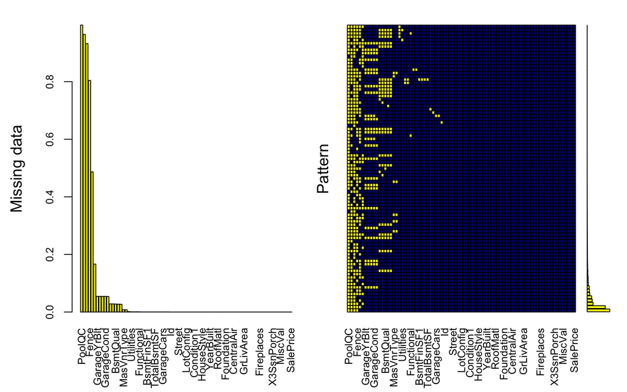

```
##
##  Variables sorted by number of missings:
##       Variable        Count
##         PoolQC 0.9965741692
##    MiscFeature 0.9640287770
##          Alley 0.9321685509
##          Fence 0.8043850634
##    FireplaceQu 0.4864679685
##    LotFrontage 0.1664953751
##    GarageYrBlt 0.0544707091
##   GarageFinish 0.0544707091
##     GarageQual 0.0544707091
##     GarageCond 0.0544707091
##     GarageType 0.0537855430
##       BsmtCond 0.0280918123
##   BsmtExposure 0.0280918123
##       BsmtQual 0.0277492292
##   BsmtFinType2 0.0274066461
##   BsmtFinType1 0.0270640630
##     MasVnrType 0.0082219938
##     MasVnrArea 0.0078794108
##       MSZoning 0.0013703323
##      Utilities 0.0006851662
##   BsmtFullBath 0.0006851662
##   BsmtHalfBath 0.0006851662
##     Functional 0.0006851662
##    Exterior1st 0.0003425831
##    Exterior2nd 0.0003425831
##     BsmtFinSF1 0.0003425831
##     BsmtFinSF2 0.0003425831
##      BsmtUnfSF 0.0003425831
##    TotalBsmtSF 0.0003425831
##     Electrical 0.0003425831
##    KitchenQual 0.0003425831
##     GarageCars 0.0003425831
##     GarageArea 0.0003425831
##       SaleType 0.0003425831
##             Id 0.0000000000
##     MSSubClass 0.0000000000
##        LotArea 0.0000000000
```

[output cut: 29 more lines]

```
##   KitchenAbvGr 0.0000000000
##   TotRmsAbvGrd 0.0000000000
##     Fireplaces 0.0000000000
##     PavedDrive 0.0000000000
##     WoodDeckSF 0.0000000000
##    OpenPorchSF 0.0000000000
##  EnclosedPorch 0.0000000000
##     X3SsnPorch 0.0000000000
##    ScreenPorch 0.0000000000
##       PoolArea 0.0000000000
##        MiscVal 0.0000000000
##         MoSold 0.0000000000
##         YrSold 0.0000000000
##  SaleCondition 0.0000000000
##      SalePrice 0.0000000000
```

```r
# display the pattern of missing values
mice_plot <- aggr(full, col=c('navyblue','yellow'),
                  numbers=TRUE, sortVars=TRUE,
                  labels=names(full), cex.axis=.8,
                  gap=3, ylab=c("Missing data","Pattern"))
```

We can further investigate how many missing values in each column in the training set and test set:

```r
missing_full <- sapply(full, function(x) sum(is.na(x)))
missing_full[missing_full!=0]
```

```
##     MSZoning  LotFrontage        Alley    Utilities  Exterior1st
##            4          486         2721            2            1
##  Exterior2nd   MasVnrType   MasVnrArea     BsmtQual     BsmtCond
##            1           24           23           81           82
## BsmtExposure BsmtFinType1   BsmtFinSF1 BsmtFinType2   BsmtFinSF2
##           82           79            1           80            1
##    BsmtUnfSF  TotalBsmtSF   Electrical BsmtFullBath BsmtHalfBath
##            1            1            1            2            2
##  KitchenQual   Functional  FireplaceQu   GarageType  GarageYrBlt
##            1            2         1420          157          159
## GarageFinish   GarageCars   GarageArea   GarageQual   GarageCond
##          159            1            1          159          159
##       PoolQC        Fence  MiscFeature     SaleType
##         2909         2348         2814            1
```

Correlation plot

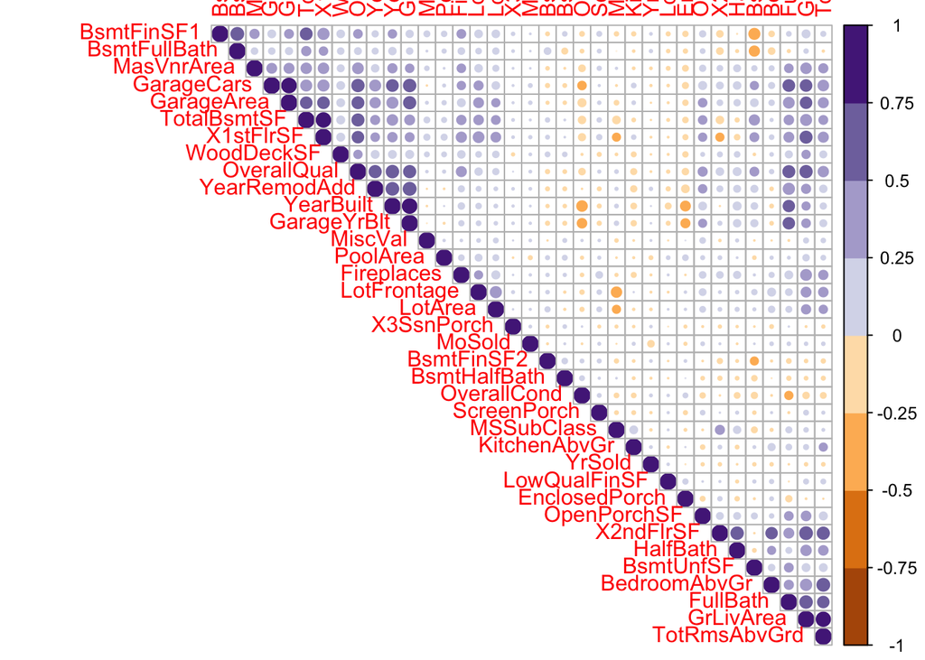

```r
M<-cor(na.omit(full[non_factor_columns]))
corrplot(M, type="upper", order="hclust",col=brewer.pal(n=8, name="PuOr"))
```

### Feature Engineering

1. Replace NA in numeric variables with their mean
2. Replace NA in categorical variables with zero
3. Generate new variables, Age, OverallQual Square and GrLivArea Square
4. Log-transform skewed variables

```r
full <- full %>% mutate(Age = YrSold - YearBuilt,
                        OverallQual_Square = OverallQual*OverallQual,
                        GrLivArea_Square = GrLivArea*GrLivArea)

all_data <- full
for (i in 1:length(non_factor_columns)){
  if (skewness(all_data[non_factor_columns[i]],na.rm = TRUE) > 0.75) {
    all_data[non_factor_columns[i]] <- log(all_data[non_factor_columns[i]]+1)
  }
}

all_data <- all_data %>% select(-Alley,-FireplaceQu,-MiscFeature,-PoolQC,-Fence)

feature_classes <- sapply(names(all_data),function(x){class(all_data[[x]])})
categorical_feats <- names(feature_classes[feature_classes == "factor"])
numeric_feats <-names(feature_classes[feature_classes != "factor"])

numeric_df <- all_data[numeric_feats]

for (x in numeric_feats) {
  mean_value <- mean(full[[x]],na.rm = TRUE)
  all_data[[x]][is.na(all_data[[x]])] <- mean_value
}

dummies <- dummyVars(~.,all_data[categorical_feats])
categorical_1 <- predict(dummies,all_data[categorical_feats])
categorical_1[is.na(categorical_1)] <- 0

all_data <- cbind(all_data[numeric_feats],categorical_1)

# create data for training and test
X_train <- all_data[1:nrow(house_prices_data),]
X_test <- all_data[(nrow(house_prices_data)+1):nrow(all_data),]
y <- log(house_prices_data$SalePrice+1)
X_train$SalePrice <- NULL
X_test$SalePrice <- NULL
X_train$Id <- NULL
X_test$Id <- NULL
x_train <- as.matrix(X_train)
x_test <-  as.matrix(X_test)
```

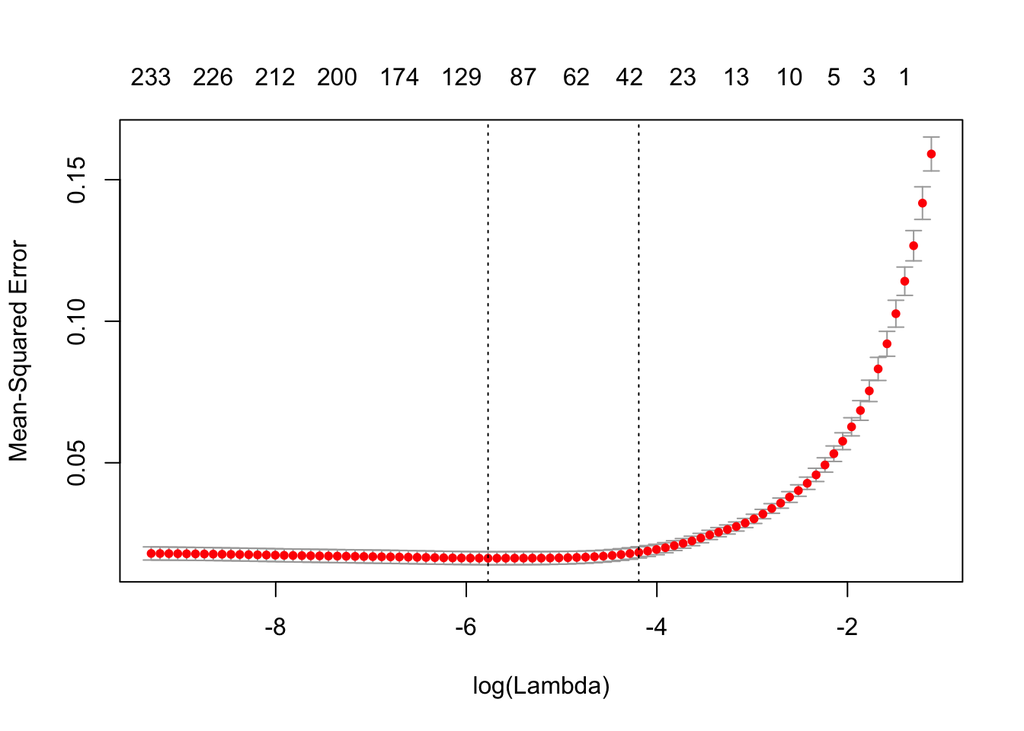

```r
cv1=cv.glmnet(x_train,y,nfolds=10,alpha=1)
plot(cv1)
```

```r
coef(cv1)
```

```
## 274 x 1 sparse Matrix of class "dgCMatrix"
##                                   1
## (Intercept)            5.561479e+00
## MSSubClass             .
## LotFrontage            .
## LotArea                6.654216e-02
## OverallQual            2.803634e-02
## OverallCond            2.388107e-02
## YearBuilt              .
## YearRemodAdd           1.043502e-03
## MasVnrArea             .
## BsmtFinSF1             8.665536e-03
## BsmtFinSF2             .
## BsmtUnfSF              .
## TotalBsmtSF            9.126474e-03
## X1stFlrSF              8.440262e-02
## X2ndFlrSF              .
## LowQualFinSF           .
## GrLivArea              3.502496e-01
## BsmtFullBath           1.456175e-02
## BsmtHalfBath           .
## FullBath               .
## HalfBath               .
## BedroomAbvGr           .
## KitchenAbvGr          -3.677758e-02
## TotRmsAbvGrd           .
## Fireplaces             2.520152e-02
## GarageYrBlt            .
## GarageCars             4.175710e-02
## GarageArea             6.179635e-05
## WoodDeckSF             6.174137e-04
## OpenPorchSF            .
## EnclosedPorch          .
## X3SsnPorch             .
## ScreenPorch            .
## PoolArea               .
## MiscVal                .
## MoSold                 .
## YrSold                 .
## Age                   -1.723483e-03
```

[output cut: 221 more lines]

```
## SaleType.COD           .
## SaleType.Con           .
## SaleType.ConLD         .
## SaleType.ConLI         .
## SaleType.ConLw         .
## SaleType.CWD           .
## SaleType.New           1.340790e-02
## SaleType.Oth           .
## SaleType.WD            .
## SaleCondition.Abnorml -2.468954e-02
## SaleCondition.AdjLand  .
## SaleCondition.Alloca   .
## SaleCondition.Family   .
## SaleCondition.Normal   .
## SaleCondition.Partial  .
```

```r
wu.predicted_values <- exp(predict(cv1,s=cv1$lambda.min,newx=x_test))
wu.predicted_values[661] <- sung.predicted_values[661]
sung.predicted_values[1090] <- wu.predicted_values[1090]
```

# Create Submission File

After getting all predicted values from the above models, we summarize the three and weight them accordingly. The weights were decided through a trial and error method that got the lowest Kaggle score. The weights are ( 0.4 Model #1 + 0.8 Model #2 + 1.8 Model #3 ) / 3.

```r
# Predict on test set and fixed some outliers
summary(wu.predicted_values)
summary(sung.predicted_values)
summary(predicted_values_lm)
predicted_values <- (0.8*sung.predicted_values + 1.8* wu.predicted_values + 0.4*predicted_values_lm)/3

# Create file for submission
submission_matrix <- data.frame(cbind(house_prices_data_test$Id, predicted_values))
colnames(submission_matrix) = c('Id', 'SalePrice')
submission_matrix$SalePrice <- round(submission_matrix$SalePrice)

# Write submission file
write.csv(submission_matrix, file='submission_file_final.csv', row.names = FALSE)
```